# NBA 2015

Maribel Crespí valero y Carlos Bosh Pino

4/25/2020

[figure not shown]

# 1 Introducción:

En baloncesto abundan estadísticas de todo tipo, así que hemos pensado que era un tema bastante idóneo a tratar en este trabajo. La elección de la NBA es debido a que es la liga más atractiva a la hora de sacar datos, ya que en ésta es donde juegan los mejores jugadores de todo el mundo y por lo tanto es un foco de talento inmenso. Un ejemplo de la inmensa cantidad de estadísticas son actuaciones históricas donde jugadores han llegado a marcar 100 puntos, dar 30 asistencias o coger 42 rebotes. De jugadores que promedian triples-dobles por temporada o incluso aquellos que han conseguido llegar al cuadruple-doble en algún partido.

**NOTA**: Un triple-doble es conseguir doble dígito en al menos tres de los datos estadísticos cuantificables tradicionales. Estos son los puntos, los rebotes, las asistencias, los robos y los tapones. Un cuadruple-doble es lo mismo pero en cuatro datos estadísticos.

Nosotros nos vamos a encargar de estudiar todas estas estadísticas, ver que cómo se relacionan unas con otras y sacar las conclusiones pertinentes. Investigaremos qué es lo que hace a un equipo el dueño de su conferencia, comparar a los mejores jugadores para ver quién es realmente eficiente para su equipo, ver la evolución de la liga y de los equipos, entre otras muchas cosas.

Los objetivos del proyecto y los apartados que se tratan son:

1. Estadísticos Descriptivos básicos globales.
2. Estadísticos Descriptivos básicos por agrupaciones.
3. Análisis multidimensional: Relación entre las variables.
4. Presentación gráfica de los resultados Anteriores.
5. Conclusiones: Interpretaciones básicas del análisis exploratorio.

EL link con los datos es: [NBA 2015](https://www.kaggle.com/drgilermo/nba-players-stats-20142015)

## 1.1 Carga de datos

```r
  data=read.csv("players_stats.csv.xls",header=TRUE)


colnames(data)<-c("Nombre","Partidos jugados","Minutos","Puntos",
                  "Canastas anotadas","Canastas intentadas",
                  "Porcentaje canastas","3P anotados",
                  "3P intentados","Porcentaje triples",
                  "Tiros libres anotados","Tiros libres intentados",
                  "Porcentaje tiros libres ","Rebotes ofensivos",
                  "Rebotes defensivos","Rebotes",
                  "Asistencias","Robos","Tapones","Perdidas","Faltas en ataque",
                  "Faltas en defensa","Asistencias/Perdida","Robo/Pérdida",
                  "Edad","Nacimiento","Fecha de nacimiento","Instituto",
                  "Experiencia","Peso","Posición","Equipo","Altura","BMI")
str(data)
```

```
## 'data.frame':    490 obs. of  34 variables:
##  $ Nombre                  : Factor w/ 490 levels "Aaron Brooks",..: 4 1 2 3 5 6 8 9 10 11 ...
##  $ Partidos jugados        : int  26 82 47 32 76 65 74 27 5 69 ...
##  $ Minutos                 : int  324 1885 797 740 2318 1992 1744 899 14 1518 ...
##  $ Puntos                  : int  133 954 243 213 1156 1082 545 374 4 432 ...
##  $ Canastas anotadas       : int  51 344 93 91 519 486 195 121 1 179 ...
##  $ Canastas intentadas     : int  137 817 208 220 965 1010 440 300 4 353 ...
##  $ Porcentaje canastas     : num  37.2 42.1 44.7 41.4 53.8 48.1 44.3 40.3 25 50.7 ...
##  $ 3P anotados             : int  15 121 13 1 11 2 73 26 0 1 ...
##  $ 3P intentados           : int  57 313 48 9 36 5 210 68 0 3 ...
##  $ Porcentaje triples      : num  26.3 38.7 27.1 11.1 30.6 40 34.8 38.2 0 33.3 ...
##  $ Tiros libres anotados   : int  16 145 44 30 107 108 82 106 2 73 ...
##  $ Tiros libres intentados : int  24 174 61 46 141 165 101 129 2 104 ...
##  $ Porcentaje tiros libres : num  66.7 83.3 72.1 65.2 75.9 65.5 81.2 82.2 100 70.2 ...
##  $ Rebotes ofensivos       : int  6 32 46 48 131 99 31 19 1 142 ...
```

[output cut: 20 more lines]

```r
head(data)
```

```
##          Nombre Partidos jugados Minutos Puntos Canastas anotadas
## 1      AJ Price               26     324    133                51
## 2  Aaron Brooks               82    1885    954               344
## 3  Aaron Gordon               47     797    243                93
## 4 Adreian Payne               32     740    213                91
## 5    Al Horford               76    2318   1156               519
## 6  Al Jefferson               65    1992   1082               486
##   Canastas intentadas Porcentaje canastas 3P anotados 3P intentados
## 1                 137                37.2          15            57
## 2                 817                42.1         121           313
## 3                 208                44.7          13            48
## 4                 220                41.4           1             9
## 5                 965                53.8          11            36
## 6                1010                48.1           2             5
##   Porcentaje triples Tiros libres anotados Tiros libres intentados
```

[output cut: 34 more lines]

# 2 Estadísticos Descriptivos básicos globales: Medias, Medianas, Desviaciones típicas y Varianzas

En este apartado, calculamos las estadísticas globales de todos los jugadores.

## 2.1 Medias y medianas:

Media, Mediana y maximos y minimos de minutos jugados:

```r
summary(data$Minutos)
```

```
##    Min. 1st Qu.  Median    Mean 3rd Qu.    Max.
##     3.0   492.2  1193.0  1214.7  1905.8  2981.0
```

Media, Mediana y maximos y minimos de puntos:

```r
summary(data$Puntos)
```

```
##    Min. 1st Qu.  Median    Mean 3rd Qu.    Max.
##     0.0   145.2   423.0   502.1   774.0  2217.0
```

Media, Mediana y maximos y minimos de canastas anotadas:

```r
summary(data$`Canastas anotadas`)
```

```
##    Min. 1st Qu.  Median    Mean 3rd Qu.    Max.
##     0.0    55.5   156.0   188.3   286.0   659.0
```

Media, Mediana y maximos y minimos de canastas intentadas:

```r
summary(data$`Canastas intentadas`)
```

```
##    Min. 1st Qu.  Median    Mean 3rd Qu.    Max.
##     0.0   139.0   357.5   419.5   642.8  1471.0
```

Media, Mediana y maximos y minimos de los porcentajes de anotación:

```r
summary(data$`Porcentaje canastas`)
```

```
##    Min. 1st Qu.  Median    Mean 3rd Qu.    Max.
##    0.00   39.60   42.90   43.10   47.58  100.00
```

Media, Mediana y maximos y minimos de triples anotados:

```r
summary(data$`3P anotados`)
```

```
##    Min. 1st Qu.  Median    Mean 3rd Qu.    Max.
##    0.00    1.00   18.00   39.39   66.00  286.00
```

Media, Mediana y maximos y minimos de triples intentados:

```r
summary(data$`3P intentados`)
```

```
##    Min. 1st Qu.  Median    Mean 3rd Qu.    Max.
##     0.0     6.0    58.0   112.5   192.0   646.0
```

Media, Mediana y maximos y minimos de porcentajes de triple:

```r
summary(data$`Porcentaje triples`)
```

```
##    Min. 1st Qu.  Median    Mean 3rd Qu.    Max.
##    0.00   15.50   31.30   25.52   36.40  100.00
```

Media, Mediana y maximos y minimos de tiros libres anotados:

```r
summary(data$`Tiros libres anotados`)
```

```
##    Min. 1st Qu.  Median    Mean 3rd Qu.    Max.
##    0.00   18.50   58.00   86.04  126.75  715.00
```

Media, Mediana y maximos y minimos de tiros libres intentados:

```r
summary(data$`Tiros libres intentados`)
```

```
##    Min. 1st Qu.  Median    Mean 3rd Qu.    Max.
##    0.00   26.25   80.00  114.69  166.75  824.00
```

Media, Mediana y maximos y minimos del porcentaje de acierto de tiros libres:

```r
summary(data$`Porcentaje tiros libres`)
```

```
##    Min. 1st Qu.  Median    Mean 3rd Qu.    Max.
##    0.00   64.35   75.00   70.45   82.00  100.00
```

Media, Mediana y maximos y minimos de rebotes ofensivos:

```r
summary(data$`Rebotes ofensivos`)
```

```
##    Min. 1st Qu.  Median    Mean 3rd Qu.    Max.
##    0.00   13.00   31.50   54.66   75.75  437.00
```

```r
summary(data$`Rebotes ofensivos`)
```

```
##    Min. 1st Qu.  Median    Mean 3rd Qu.    Max.
##    0.00   13.00   31.50   54.66   75.75  437.00
```

Media, Mediana y maximos y minimos de rebotes en general:

```r
summary(data$Rebotes)
```

```
##    Min. 1st Qu.  Median    Mean 3rd Qu.    Max.
##    0.00   70.25  176.00  217.35  314.75 1226.00
```

Media, Mediana y maximos y minimos de asistencias:

```r
summary(data$Asistencias)
```

```
##    Min. 1st Qu.  Median    Mean 3rd Qu.    Max.
##     0.0    24.0    70.0   110.6   150.8   838.0
```

Media, Mediana y maximos y minimos de robos de balón:

```r
summary(data$Robos)
```

```
##    Min. 1st Qu.  Median    Mean 3rd Qu.    Max.
##    0.00   12.25   32.00   38.84   55.50  163.00
```

Media, Mediana y maximos y minimos de tapones:

```r
summary(data$Tapones)
```

```
##    Min. 1st Qu.  Median    Mean 3rd Qu.    Max.
##    0.00    5.00   14.00   24.08   29.75  200.00
```

Media, Mediana y maximos y minimos de pérdidas de balón:

```r
summary(data$`Perdidas`)
```

```
##    Min. 1st Qu.  Median    Mean 3rd Qu.    Max.
##    0.00   23.00   56.50   68.83  100.00  321.00
```

Media, Mediana y maximos y minimos de faltas en ataque:

```r
summary(data$`Faltas en ataque`)
```

```
##    Min. 1st Qu.  Median    Mean 3rd Qu.    Max.
##     0.0    45.5   103.0   101.5   148.8   285.0
```

Media, Mediana y maximos y minimos de faltas en defensa:

```r
summary(data$`Faltas en defensa`)
```

```
##    Min. 1st Qu.  Median    Mean 3rd Qu.    Max.
##    -3.0   165.0   490.5   564.3   837.0  2202.0
```

Media, Mediana y maximos y minimos de la edad de los jugadores:

```r
summary(data$Edad)
```

```
##    Min. 1st Qu.  Median    Mean 3rd Qu.    Max.    NA's
##   20.00   24.00   27.00   27.51   30.00   39.00      68
```

## 2.2 Desviaciones típicas:

Desviación típica de minutos jugados:

```r
sd(data$Minutos)
```

```
## [1] 820.5701
```

Desviación típica de puntos:

```r
sd(data$Puntos)
```

```
## [1] 422.0842
```

Desviación típica de canastas anotadas:

```r
sd(data$`Canastas anotadas`)
```

```
## [1] 156.2658
```

Desviación típica de canastas intentadas:

```r
sd(data$`Canastas intentadas`)
```

```
## [1] 337.3671
```

Desviación típica de los porcentajes de anotación:

```r
sd(data$`Porcentaje canastas`)
```

```
## [1] 9.625231
```

Desviación típica de triples anotados:

```r
sd(data$`3P anotados`)
```

```
## [1] 47.88091
```

Desviación típica de triples intentados:

```r
sd(data$`3P intentados`)
```

```
## [1] 127.3857
```

Desviación típica de porcentajes de triple:

```r
sd(data$`Porcentaje triples`)
```

```
## [1] 15.7966
```

Desviación típica de tiros libres anotados:

```r
sd(data$`Tiros libres anotados`)
```

```
## [1] 91.31532
```

Desviación típica de tiros libres intentados:

```r
sd(data$`Tiros libres intentados`)
```

```
## [1] 115.1392
```

Desviación típica del porcentaje de acierto de tiros libres:

```r
sd(data$`Porcentaje tiros libres`)
```

```
## [1] 19.08782
```

Desviación típica de rebotes ofensivos:

```r
sd(data$`Rebotes ofensivos`)
```

```
## [1] 61.06604
```

```r
sd(data$`Rebotes ofensivos`)
```

```
## [1] 61.06604
```

Desviación típica de rebotes en general:

```r
sd(data$Rebotes)
```

```
## [1] 191.9839
```

Desviación típica de asistencias:

```r
sd(data$Asistencias)
```

```
## [1] 125.9821
```

Desviación típica de robos de balón:

```r
sd(data$Robos)
```

```
## [1] 33.38951
```

Desviación típica de tapones:

```r
sd(data$Tapones)
```

```
## [1] 31.66285
```

Desviación típica de pérdidas de balón:

```r
sd(data$`Perdidas`)
```

```
## [1] 58.4807
```

Desviación típica de faltas en ataque:

```r
sd(data$`Faltas en ataque`)
```

```
## [1] 65.32681
```

Desviación típica de faltas en defensa:

```r
sd(data$`Faltas en defensa`)
```

```
## [1] 464.428
```

## 2.3 Varianzas:

Varianza de minutos jugados:

```r
var(data$Minutos)
```

```
## [1] 673335.3
```

Varianza de puntos:

```r
var(data$Puntos)
```

```
## [1] 178155.1
```

Varianza de canastas anotadas:

```r
var(data$`Canastas anotadas`)
```

```
## [1] 24418.99
```

Varianza de canastas intentadas:

```r
var(data$`Canastas intentadas`)
```

```
## [1] 113816.6
```

Varianza de los porcentajes de anotación:

```r
var(data$`Porcentaje canastas`)
```

```
## [1] 92.64507
```

Varianza de triples anotados:

```r
var(data$`3P anotados`)
```

```
## [1] 2292.581
```

Varianza de triples intentados:

```r
var(data$`3P intentados`)
```

```
## [1] 16227.13
```

Varianza de porcentajes de triple:

```r
var(data$`Porcentaje triples`)
```

```
## [1] 249.5327
```

Varianza de tiros libres anotados:

```r
var(data$`Tiros libres anotados`)
```

```
## [1] 8338.487
```

Varianza de tiros libres intentados:

```r
var(data$`Tiros libres intentados`)
```

```
## [1] 13257.04
```

Varianza del porcentaje de acierto de tiros libres:

```r
var(data$`Porcentaje tiros libres`)
```

```
## [1] 364.3448
```

Varianza de rebotes ofensivos:

```r
var(data$`Rebotes ofensivos`)
```

```
## [1] 3729.061
```

```r
var(data$`Rebotes ofensivos`)
```

```
## [1] 3729.061
```

Varianza de rebotes en general:

```r
var(data$Rebotes)
```

```
## [1] 36857.82
```

Varianza de asistencias:

```r
var(data$Asistencias)
```

```
## [1] 15871.48
```

Varianza de robos de balón:

```r
var(data$Robos)
```

```
## [1] 1114.859
```

Varianza de tapones:

```r
var(data$Tapones)
```

```
## [1] 1002.536
```

Varianza de pérdidas de balón:

```r
var(data$`Perdidas`)
```

```
## [1] 3419.992
```

Varianza de faltas en ataque:

```r
var(data$`Faltas en ataque`)
```

```
## [1] 4267.592
```

Varianza de faltas en defensa:

```r
var(data$`Faltas en defensa`)
```

```
## [1] 215693.4
```

# 3 Estadísticas descriptivas básicas por agrupaciones:

Hemos decidido escoger los cuatro mejores equipos de la liga. Los dos mejores de la conferencia Oeste( Golden State Warriors y Houston Rockets) y los dos mejores de la conferencia Este(Atlanta Hawks y Cleveland Cavaliers).

```r
Mejores_equipos=c("GSW","CLE","HOU","ATL")
data2=data[as.character(data$Equipo)%in% Mejores_equipos,c("Equipo","Puntos",
                                                           "Asistencias","Rebotes")]
data2=na.omit(data2)
summary(data2$Puntos)
```

```
##    Min. 1st Qu.  Median    Mean 3rd Qu.    Max.
##       4     182     390     584     855    2217
```

```r
sd(data2$`Asistencias`)
```

```
## [1] 158.2523
```

```r
var(data2$Rebotes)
```

```
## [1] 35635.78
```

## 3.1 Representaciones gráficas:

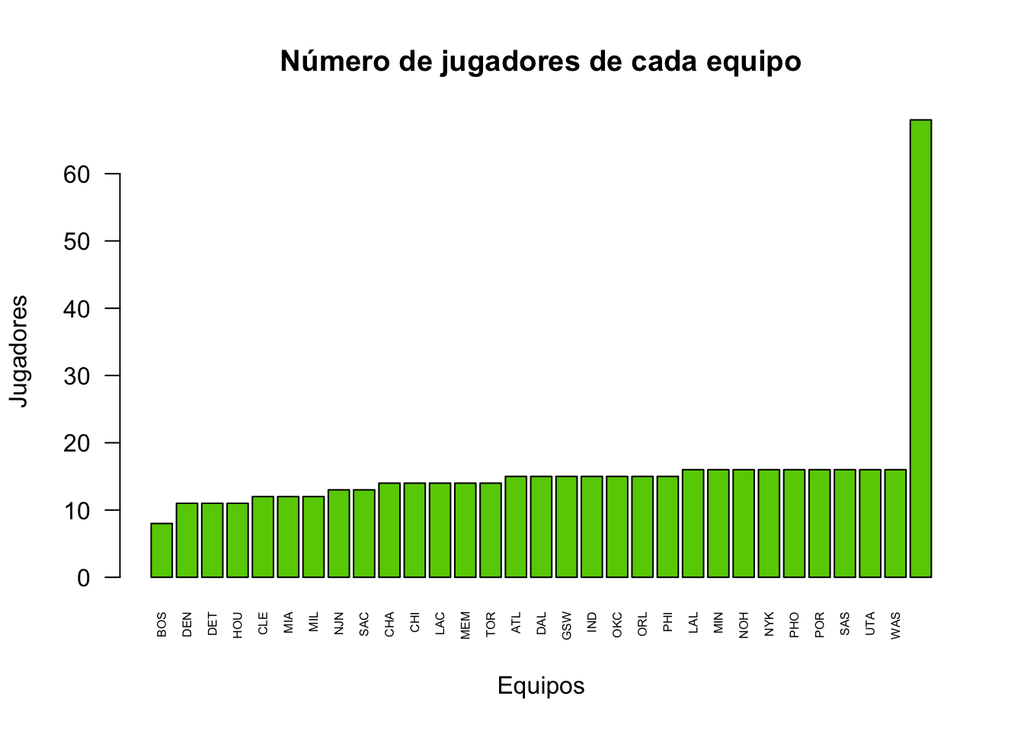

```r
barplot(sort(table(data$Equipo)),las=2,cex.names = 0.5,col="chartreuse3",
        main="Número de jugadores de cada equipo",xlab="Equipos",ylab="Jugadores")
```

En el gráfico podemos ver como en general el número de jugadores por equipo está bastante balanceado. Algunos equipos optan por una plantilla más corta pero con jugadores estrella con salarios más elevados. Otros equipos optan por más jugadores de nivel medio pero de salarios más reducidos. En general los equipos con las super estrellas mejor pagadas, son con los que menor plantel cuentan. Un ejemplo podría ser Cleveland Cavaliers, cuyo plantel cuenta con LeBron James y Kyrie Irving, dos jugadores de contrato máximo. Por lo tanto dejan poco espacio salarial para los otros jugadores.

**NOTA**: Todos los equipos de la NBA tienen un límite salarial.

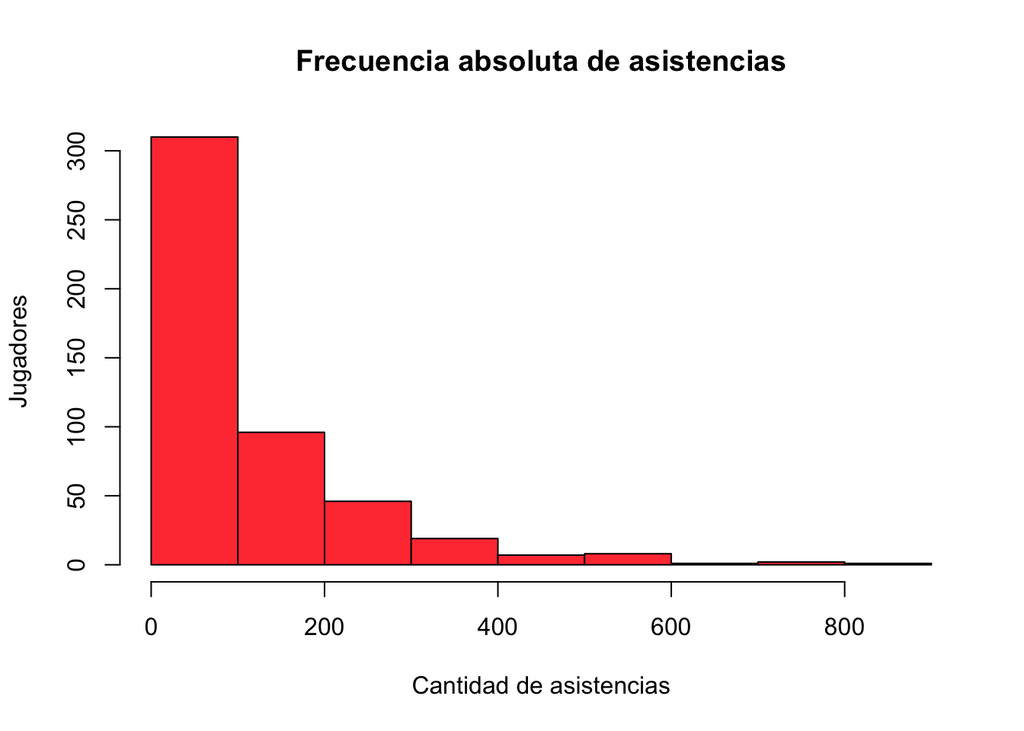

```r
hist(data$`Asistencias`,main = "Frecuencia absoluta de asistencias",
     xlab = "Cantidad de asistencias", ylab = "Jugadores",col="brown1")
```

Cantidad de asistencias por jugador.

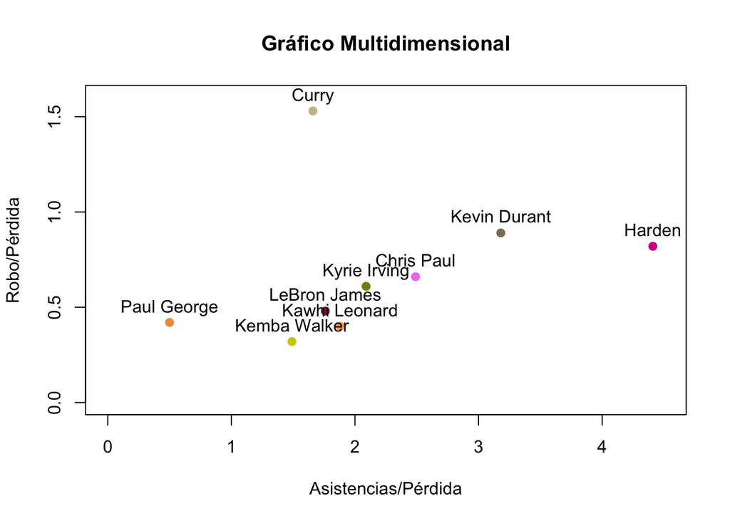

```r
Jugadores_top=c("James Harden","LeBron James","Stephen Curry","Kevin Durant",
                "Kemba Walker","Kyrie Irving","Kawhi Leonard","Paul George",
                "Chris Paul")
data3=data[as.character(data$Nombre)%in% Jugadores_top,23:24]
data3=na.omit(data3)
plot(data3,col=c("violetred","violetred4","wheat3","wheat4",
                 "yellow3","yellow4","tan1","tan2","violet"),
     main="Gráfico Multidimensional",xlab="Asistencias/Pérdida",
     pch=19,xlim=c(0,4.5),ylim=c(0,1.6))
text(data3,labels=c("Harden","LeBron James","Curry","Kevin Durant",
                    "Kemba Walker","Kyrie Irving","Kawhi Leonard",
                    "Paul George","Chris Paul"),pos=c(rep(3,times=9)))
```

## 3.2 Altura relacionada con otros datos:

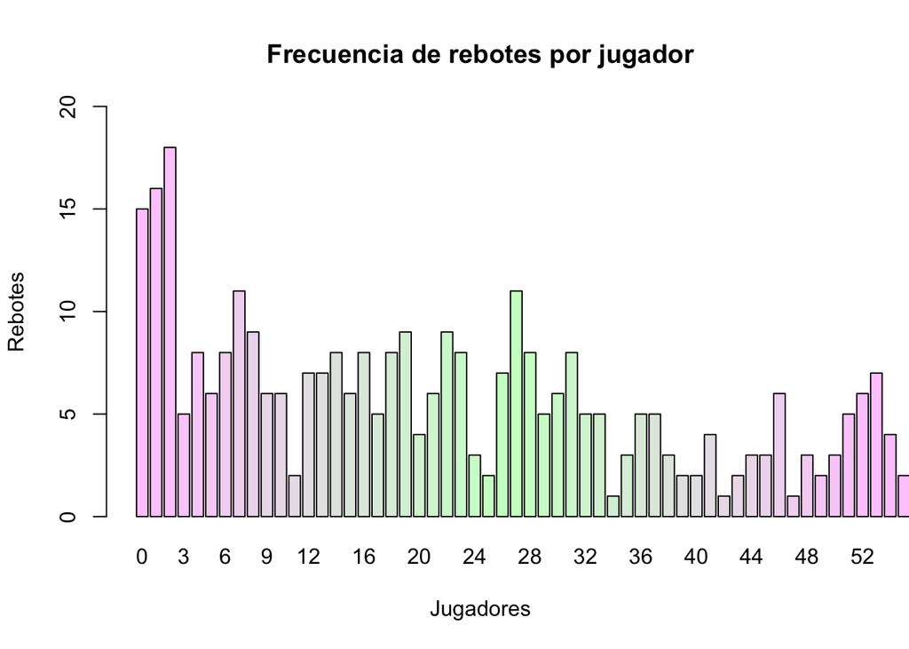

```r
mis.colores.2 <- colorRampPalette(c("#ffccff", "#ccffcc", "#ffccff"))
barplot(table(data$`Rebotes ofensivos`), main = "Frecuencia de rebotes por jugador",
        xlab = "Jugadores", ylab = "Rebotes", col = mis.colores.2(54),xlim=c(0,60),ylim=c(0,20))
```

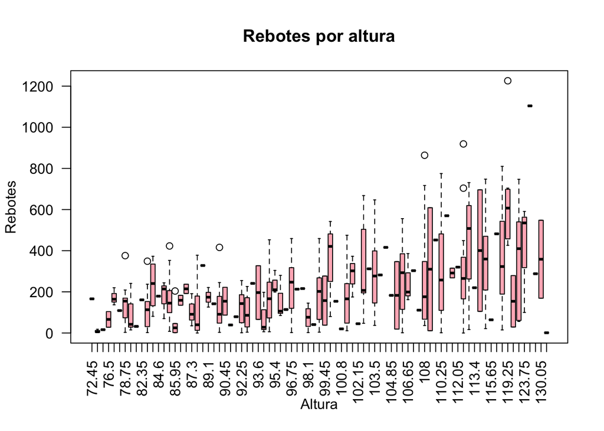

```r
boxplot(data$Rebotes~data$Altura,col="lightpink", las=2, cex.label=2,xlab="Altura",
        ylab="Rebotes",main="Rebotes por altura")
```

Este gráfico nos muestra la cantidad de rebotes totales que cogen los jugadores en relación a su altura. Como era de esperar, los jugadores más altos por lo general, son los que más rebotes capturan.

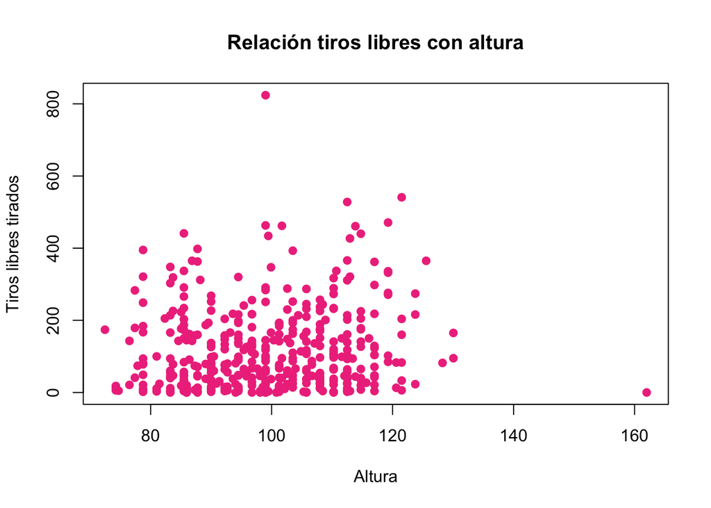

```r
plot(data$`Tiros libres intentados`~data$Altura,
     xlab= "Altura", ylab="Tiros libres tirados",
     col="violetred2",main="Relación tiros libres con altura",
     pch=19)
```

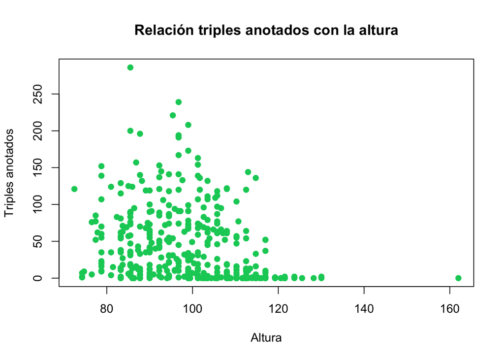

```r
plot(data$`3P anotados`~data$Altura,xlab= "Altura",
     ylab="Triples anotados",col="springgreen3",
     main="Relación triples anotados con la altura",pch=19)
```

Podemos comprobar como los mejores triplistas son jugadores de estatura “media” en la nba. De hecho, tiene bastante sentido, ya que cuando pensamos en jugadores de mayor estatura, los relacionamos inevitablemente cerca de la canasta, posteando o reboteando. Sería un “desperdicio” posicionarlos lejos de donde supuestamente tienen una ventaja. En cambio, los jugadores de menor estatura, suelen ser los que están más lejos del aro y por lo tanto es normal que estos sean los que más se atrevan desde el perímetro. Además, los jugadores bajitos también suelen ser mejores en el triple ya que tienen el centro de gravedad más bajo y pueden efectuar una buena mecánica de tiro de forma mucho más rápida.

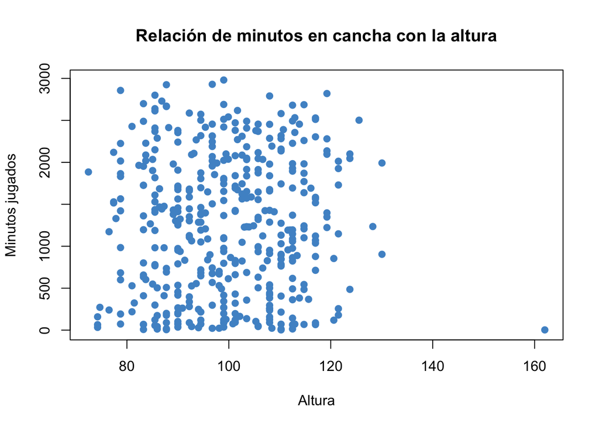

```r
plot(data$Minutos~data$Altura,xlab= "Altura", ylab="Minutos jugados",
     col="steelblue3",main="Relación de minutos en cancha con la altura",
     pch=19)
```

Cabría esperar que los jugadores más altos son los que más juegan en baloncesto, pero este gráfico nos desmiente ese mito. A pesar de que la altura en la NBA es importante; no es imprescindible. Como podemos observar, los minutos están bastante repartidos entre jugadores de todos los tamaños. De jugadores bajitos jugando casi 3000 minutos, a jugadores enormes jugando no más de 1000, y viceversa. El talento también influye mucho.

```r
NBA_CURRY=data %>% filter(Equipo=="GSW",Nombre=="Stephen Curry") %>% summarise(
                                                        Nombre="Stephen Curry",
                                                        Triples=max(`3P anotados`),
                                                        Asistencias=max(Asistencias),
                                                        Robos=max(Robos),
                                                        Tapones=max(Tapones))
knitr::kable(NBA_CURRY)
```

| Nombre | Triples | Asistencias | Robos | Tapones |
| --- | --- | --- | --- | --- |
| Stephen Curry | 286 | 619 | 163 | 16 |

```r
NBA_LILLARD=data %>% filter(Equipo=="POR",Nombre=="Damian Lillard") %>% summarise(
                                                        Nombre="Damian Lillard",
                                                        Triples=max(`3P anotados`),
                                                        Asistencias=max(Asistencias),
                                                        Robos=max(Robos),
                                                        Tapones=max(Tapones))

knitr::kable(NBA_LILLARD)
```

| Nombre | Triples | Asistencias | Robos | Tapones |
| --- | --- | --- | --- | --- |
| Damian Lillard | 196 | 507 | 97 | 21 |

Datos de jugadores concretos. En este caso he seleccionado a Stephen Curry y Damian Lillard porque son dos de los bases más destacados de la liga.

```r
Instituto= table(data$Instituto)
head(Instituto)
```

```
##
##                          Arizona State University        Baylor University
##                      140                        2                        4
##       Belmont University            Blinn College           Boston College
##                        1                        1                        2
```

```r
max(Instituto)
```

```
## [1] 140
```

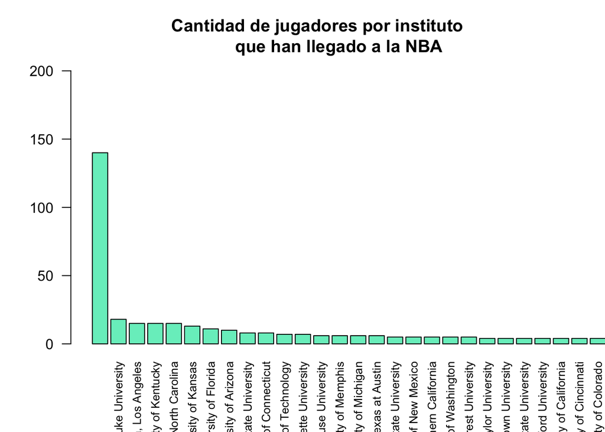

```r
barplot(sort(Instituto,decreasing=TRUE),
        las=2,cex.names = 0.8,main="Cantidad de jugadores por instituto
        que han llegado a la NBA",
        xlab="", col="aquamarine2",ylim=c(0,200),xlim=c(0,30))
```

Como podemos ver, en general los jugadores que llegaron a la NBA se han distribuido a lo largo de todas las universidades de los 50 estados. Sin embargo, algunas universidades tienen más caché que otras, son vistas con mejores ojos por los jugadores y los analistas, por lo que generalmente los mejores prospectos se marchan a las mejores universidades.

Se puede ver como una sobresale por encima de todas, pero en este caso son los jugadores que no han asistido a la universidad, ya sea porque han llegado del instituto a la NBA directamente, o por que estuvieron jugando en otras ligas.

De las universidades más escogidas encontramos Duke University. Esto no es de estrañar ya que es de las más prestigiosas. Aquí han nacido grandes jugadores como Kyrie Irving, Zion Williamson o Jayson Tatum, entre otros.

```r
NBA_resumen_season= data %>% group_by(Equipo) %>% summarise(N=n(),
                                                       Mean_pts=mean(Puntos),
                                                       Sd_pts=sd(Puntos),
                                                       Max_pts=max(Puntos),
                                                       Min_pts=min(Puntos))
NBA_resumen_season
```

```
## # A tibble: 31 x 6
##    Equipo     N Mean_pts Sd_pts Max_pts Min_pts
##    <fct>  <int>    <dbl>  <dbl>   <int>   <int>
##  1 ""        68     417.   387.    1886       0
##  2 "ATL"     15     573.   404.    1218      96
##  3 "BOS"      8     648.   392.    1101      24
##  4 "CHA"     14     518.   375.    1082      41
##  5 "CHI"     14     590.   455.    1446      10
##  6 "CLE"     12     544    642.    1743       4
##  7 "DAL"     15     588.   443.    1513      44
##  8 "DEN"     11     519.   408.    1143       3
##  9 "DET"     11     531.   420.    1130      36
## 10 "GSW"     15     640.   549.    1900      20
## # … with 21 more rows
```

```r
knitr::kable(NBA_resumen_season)
```

| Equipo | N | Mean_pts | Sd_pts | Max_pts | Min_pts |
| --- | --- | --- | --- | --- | --- |
|  | 68 | 416.5735 | 387.2092 | 1886 | 0 |
| ATL | 15 | 572.7333 | 404.1010 | 1218 | 96 |
| BOS | 8 | 648.5000 | 391.5993 | 1101 | 24 |
| CHA | 14 | 518.4286 | 374.8462 | 1082 | 41 |
| CHI | 14 | 590.3571 | 454.9346 | 1446 | 10 |
| CLE | 12 | 544.0000 | 641.9919 | 1743 | 4 |
| DAL | 15 | 588.2667 | 442.8538 | 1513 | 44 |
| DEN | 11 | 518.8182 | 407.6299 | 1143 | 3 |
| DET | 11 | 530.9091 | 419.5992 | 1130 | 36 |
| GSW | 15 | 639.6000 | 548.6547 | 1900 | 20 |
| HOU | 11 | 567.0000 | 645.9474 | 2217 | 32 |
| IND | 15 | 544.0000 | 273.1182 | 942 | 53 |
| LAC | 14 | 574.7857 | 582.2333 | 1564 | 18 |
| LAL | 16 | 456.7500 | 331.0465 | 841 | 2 |
| MEM | 14 | 574.0714 | 466.9939 | 1413 | 0 |
| MIA | 12 | 360.5000 | 352.4621 | 1007 | 3 |
| MIL | 12 | 503.5833 | 365.4592 | 1055 | 20 |
| MIN | 16 | 383.8125 | 294.0447 | 917 | 22 |
| NJN | 13 | 470.1538 | 440.9289 | 1236 | 3 |
| NOH | 16 | 542.8750 | 453.5050 | 1656 | 2 |
| NYK | 16 | 449.6875 | 239.1693 | 966 | 128 |
| OKC | 15 | 530.4667 | 357.5410 | 1163 | 63 |
| ORL | 15 | 523.1333 | 446.2682 | 1428 | 37 |
| PHI | 15 | 362.0000 | 331.6855 | 966 | 17 |
| PHO | 16 | 503.6250 | 519.7365 | 1377 | 0 |
| POR | 16 | 587.3125 | 518.8004 | 1720 | 24 |
| SAC | 13 | 526.4615 | 499.5402 | 1432 | 2 |
| SAS | 16 | 531.5000 | 353.8224 | 1070 | 62 |
| TOR | 14 | 562.7857 | 492.3390 | 1244 | 6 |
| UTA | 16 | 421.7500 | 454.5755 | 1463 | 0 |
| WAS | 16 | 434.6875 | 334.1101 | 1001 | 6 |

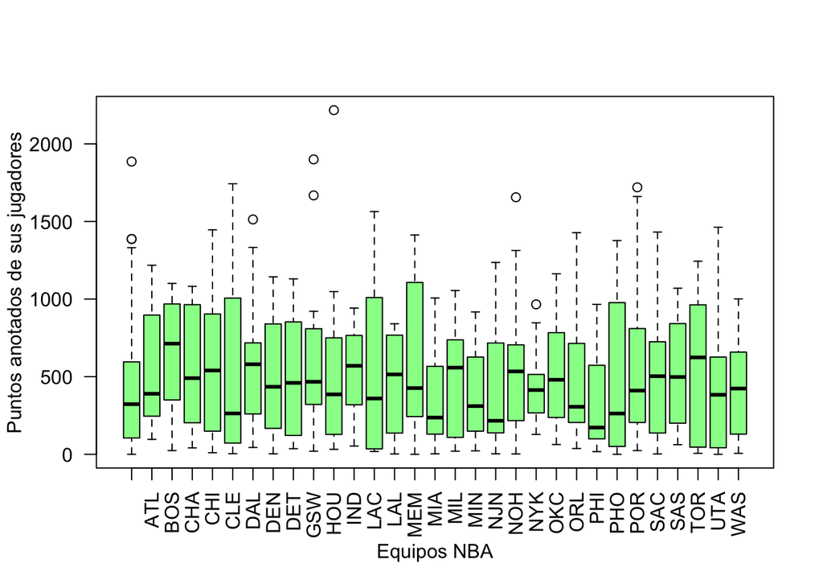

```r
boxplot(data$Puntos~data$Equipo,las=2,col="palegreen",xlab="Equipos NBA",
        ylab="Puntos anotados de sus jugadores")
```

Como conclusión final, la anotación en la NBA es muy importante, ya que los equipos con bajo porcentaje de anotación se han visto mermados por este aspecto hasta el punto de caer al fondo de la clasificación. Sin embargo, si un equipo NBA quiere aspirar a lo más alto, deberá tener en cuenta tanto ataque como defensa, ya que sin este último se quedarán en un buen equipo y nada más.

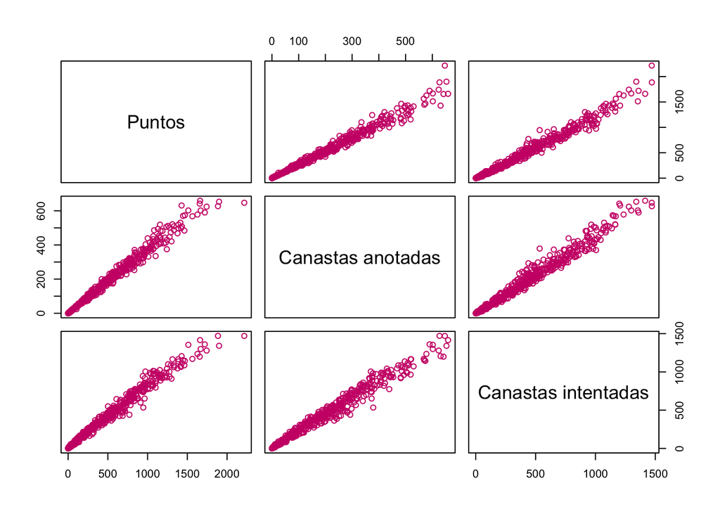

```r
plot(data[,4:6],col="deeppink3")
```

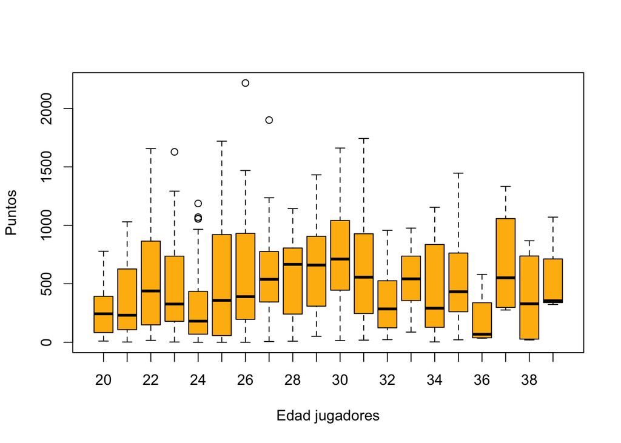

```r
boxplot(data$Puntos~data$Edad,xlab="Edad jugadores",
        ylab="Puntos",col="darkgoldenrod1")
```

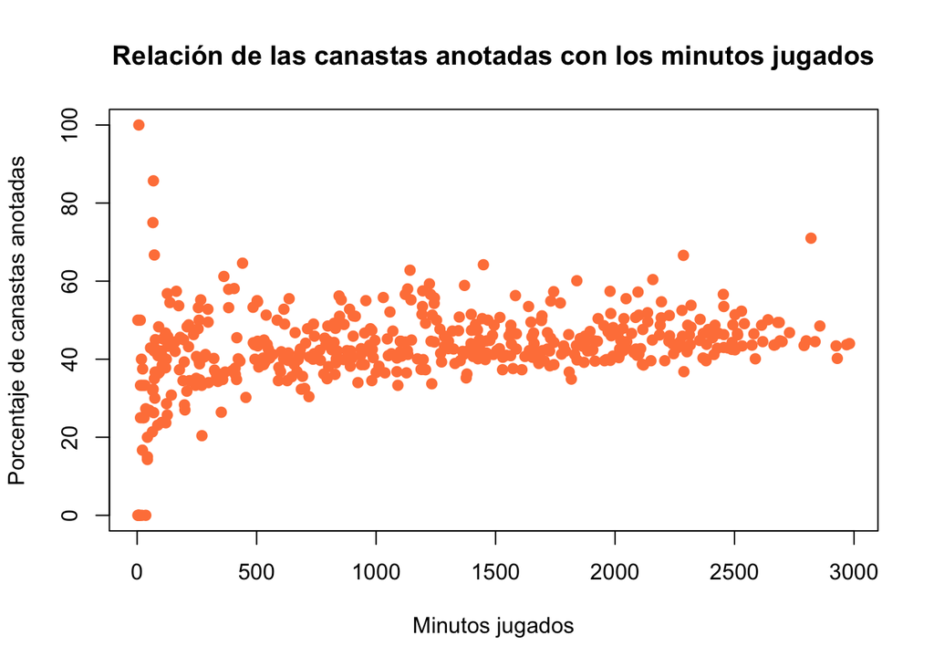

```r
plot(data$`Porcentaje canastas`~data$Minutos,xlab= "Minutos jugados",
     ylab="Porcentaje de canastas anotadas",col="sienna1",
     main="Relación de las canastas anotadas con los minutos jugados",
     pch=19)
```

Podemos observar como la muestra se distribuye de forma bastante uniforme a lo largo del gráfico. Esto quiere decir que en general los porcentajes, tanto de jugadores con un rol de suplente, como de los que son titulares indiscutibles, son bastante similares.

Lo que uno podría pensar es que los jugadores que juegan más minutos, deberían tener los porcentajes más elevados, puesto que son los más talentosos y sin embargo no es así. Esto se debe a que los jugadores que juegan más, generalmente asumen más responsabilidades y por tanto tiran más. En cambio, los jugadores cuya función es más de rol, suelen seleccionar pocos tiros, pero que suelan ser más efectivos ya que buscan la máxima eficiencia para lograr entrar en el quinteto titular. Además, como pequeño apunte, muchos de las estrellas de la nba buscan inflar estadísticas, así que no es de extrañar que tiren de forma desmedida solo para su beneficio propio. Por lo que aunque la situación de tiro no sea la idónea(por lo tanto las posibilidades de anotar sean menores), lo asuman igual.

# 4 Aplicaciones de estadística de inferencia a los datos

## 4.1 Bondad de ajuste con X^2 de Pearson

```r
FreEquipo=table(data$Equipo)
chisq.test(FreEquipo)
```

```
##
##  Chi-squared test for given probabilities
##
## data:  FreEquipo
## X-squared = 185.67, df = 30, p-value < 2.2e-16
```

```r
x=data$Robos
ks.test(x,"pnorm",3,1)
```

```
##
##  One-sample Kolmogorov-Smirnov test
##
## data:  x
## D = 0.85375, p-value < 2.2e-16
## alternative hypothesis: two-sided
```

## 4.2 Anova 1

A continuación vamos a realizar un análisis de la varianza( *ANOVA*) para comparar entre las siguientes hipótesis:

$$\left\{\begin{array}{ll}
H_{0}:\ Media \ Equipo\ 1 = \ Media \ Equipo\ 2\\
H_{1}:\ Media \ Equipo\ 1 \not= \ Media \ Equipo\ 2
\end{array}
\right.$$

Primero, se puede ver un boxplot, donde se pueden apreciar qué variables hemos escogido para realizar el *ANOVA*.

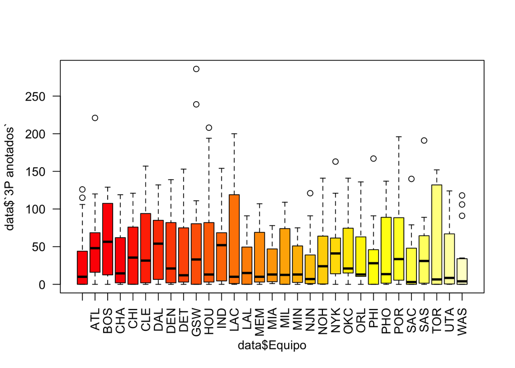

```r
boxplot(data$`3P anotados`~data$Equipo,col=heat.colors(32),las=2)
```

A continuación realizamos el anova comparando los triples anotados por equipo.

```r
data=na.omit(data)
sol_anova=aov(data$`3P anotados`~data$Equipo)
summary(sol_anova)
```

```
##              Df Sum Sq Mean Sq F value Pr(>F)
## data$Equipo  29  42521    1466   0.582  0.961
## Residuals   392 987571    2519
```

## 4.3 Test KS

A continuación vamos a realizar el test de Kolmogorov-Smirnov que utilizaremos para verificar si nuestro conjunto de datos se adapta a una distribución normal o no. Por consiguiente nuestro contraste será:

$$\left\{\begin{array}{ll}
H_{0}:\ Los \ datos\ proceden\ de\ una\ distribución\ normal \\
H_{1}:\ Los \ datos\ no\ proceden\ de\ una\ distribución\ normal
\end{array}
\right.$$

Para la realización de este apartado hemos cogido 4 equipos y hemos realizado 4 test ks, uno para cada muestra. La elección del número de equipos es simplemente por comodidad y porque hemos pensado que con esta cantidad ya sería suficiente para llegar a conclusiones más generales. Los equipos seleccionados son los que se encuentran en la parte alta de la clasificación.

```r
Mejores_equipos=c("GSW","CLE","HOU","ATL")
data4=data[as.character(data$Equipo)%in% Mejores_equipos,c("Equipo","Puntos",
                                                           "Asistencias","Rebotes")]
data4=na.omit(data4)
data4
```

```
##     Equipo Puntos Asistencias Rebotes
## 4      ATL    213          30     162
## 5      ATL   1156         244     544
## 9      CLE      4           1       1
## 21     GSW    604         228     257
## 26     GSW    422         180     543
## 54     GSW     30          12      41
## 55     CLE     35           2      29
## 83     HOU     32           2      36
## 103    GSW    388          85     257
## 111    ATL    883         118     372
## 112    ATL    768         317     164
## 123    HOU    855         130     421
## 126    GSW    921         291     647
## 130    HOU    646          50     431
```

[output cut: 39 more lines]

```r
X=data4$Puntos
F=as.factor(as.character(data4$Equipo))
levels(F)
```

```
## [1] "ATL" "CLE" "GSW" "HOU"
```

```r
muestra1=X[F=="GSW"]
ks.test(muestra1,"pnorm",mean(muestra1),sd(muestra1))
```

```
##
##  One-sample Kolmogorov-Smirnov test
##
## data:  muestra1
## D = 0.17068, p-value = 0.7134
## alternative hypothesis: two-sided
```

```r
muestra2=X[F=="CLE"]
ks.test(muestra2,"pnorm",mean(muestra2),sd(muestra2))
```

```
##
##  One-sample Kolmogorov-Smirnov test
##
## data:  muestra2
## D = 0.30367, p-value = 0.177
## alternative hypothesis: two-sided
```

```r
muestra3=X[F=="HOU"]
ks.test(muestra3,"pnorm",mean(muestra3),sd(muestra3))
```

```
##
##  One-sample Kolmogorov-Smirnov test
##
## data:  muestra3
## D = 0.20377, p-value = 0.6797
## alternative hypothesis: two-sided
```

```r
muestra4=X[F=="ATL"]
ks.test(muestra4,"pnorm",mean(muestra4),sd(muestra4))
```

```
##
##  One-sample Kolmogorov-Smirnov test
##
## data:  muestra4
## D = 0.20777, p-value = 0.4743
## alternative hypothesis: two-sided
```

Hemos decidido crear una tabla más pequeña solo con los datos que nos interesan y con los equipos seleccionados. Y previamente hemos realizado los test KS. Como vemos, el p-valor de todos los test es bastante alto, por lo que no podemos rechazar la hipótesis nula, por lo que concluimos que los datos proceden de una distribución normal.

A continuación realizamos el histograma de puntos de los Golden State Warriors:

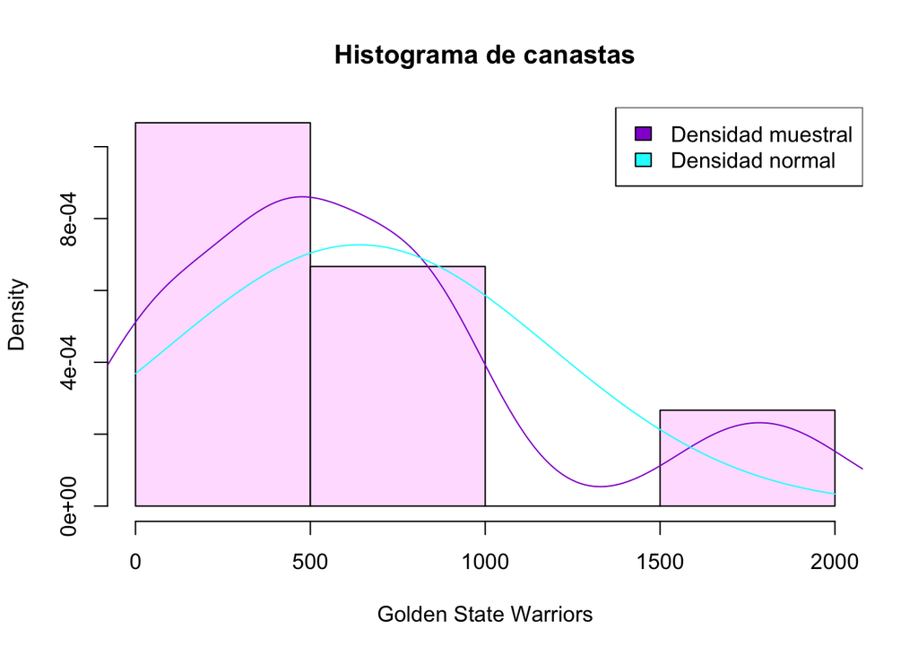

```r
hist(muestra1,freq =FALSE,main="Histograma de canastas",xlab="Golden State Warriors",
     col="thistle1")
lines(density(muestra1),col="darkviolet")
curve(dnorm(x,mean(muestra1),sd(muestra1)),add=TRUE,col="cyan")
legend("topright",c("Densidad muestral","Densidad normal"),fill=c("darkviolet","cyan"))
```

En el gráfico podemos ver la comparación entre la densidad muestral y la normal. Vemos como la empírica oscila de forma más bruca que la normal.

## 4.4 Boxplot de Puntos por equipo

[figure not shown]

```r
F2=F
levels(F2)=paste0(c("Warriors","Cavaliers","Houston Rockets","Atlanta Hawks"))
boxplot(X~F2,main="Boxplot de puntos por equipo",col="darkseagreen1")
```

En este boxplot vemos las comparaciones entre los mejores equipos de la liga.

## 4.5 Segunda ANOVA

A continuación vamos a realizar un segundo anova entre los puntos anotador por cada equipo.

```r
sola_aov=aov(X~F)
summary(sola_aov)
```

```
##             Df   Sum Sq Mean Sq F value Pr(>F)
## F            3    70653   23551   0.076  0.973
## Residuals   49 15206645  310340
```

## 4.6 Comparación de medias dos a dos con ajuste de Bonferrori

```r
pairwise.t.test(X,F,p.adjust.method = "bonferroni")
```

```
##
##  Pairwise comparisons using t tests with pooled SD
##
## data:  X and F
##
##     ATL CLE GSW
## CLE 1   -   -
## GSW 1   1   -
## HOU 1   1   1
##
## P value adjustment method: bonferroni
```

```r
cluster4=kmeans(data4[,2:4],centers = 4)
table(cluster4$cluster,F)
```

```
##    F
##     ATL CLE GSW HOU
##   1   0   2   2   1
##   2   6   2   4   2
##   3   5   2   5   3
##   4   4   6   4   5
```

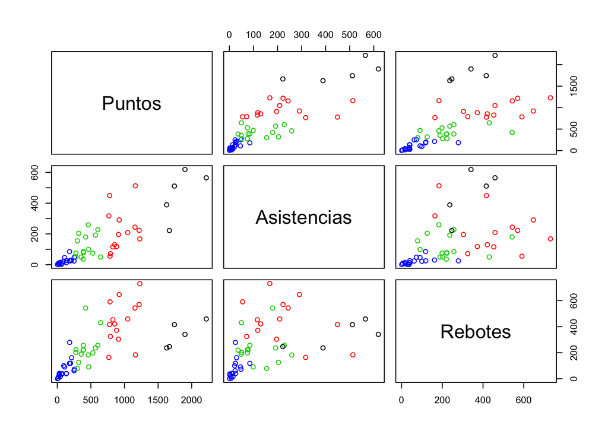

```r
plot(data2[,2:4],col=cluster4$cluster)
```

```r
estadisticos=function(x) c(media=mean(x),sd=sd(x),min=min(x),mediana=median(x),max=max(x))
aggregate(data4[,2],list(cluster4$cluster),estadisticos)
```

```
##   Group.1    x.media       x.sd      x.min  x.mediana      x.max
## 1       1 1831.20000  239.41533 1628.00000 1743.00000 2217.00000
## 2       2  952.28571  173.62534  768.00000  897.00000 1228.00000
## 3       3  425.93333  118.01965  276.00000  390.00000  646.00000
## 4       4  109.10526   83.31726    4.00000   96.00000  254.00000
```

```r
aggregate(data4[,3],list(cluster4$cluster),estadisticos)
```

```
##   Group.1   x.media      x.sd     x.min x.mediana     x.max
## 1       1 461.20000 158.57553 222.00000 511.00000 619.00000
## 2       2 221.50000 134.49149  55.00000 202.50000 513.00000
## 3       3 121.06667  74.29234  36.00000  85.00000 259.00000
## 4       4  21.21053  20.75674   1.00000  15.00000  85.00000
```

```r
aggregate(data4[,4],list(cluster4$cluster),estadisticos)
```

```
##   Group.1   x.media      x.sd     x.min x.mediana     x.max
## 1       1 340.00000  98.98990 237.00000 341.00000 459.00000
## 2       2 441.57143 165.82879 164.00000 437.00000 731.00000
## 3       3 230.60000 119.12107  79.00000 220.00000 543.00000
## 4       4  68.73684  66.81969   1.00000  41.00000 279.00000
```

## 4.7 Clustering

```r
X1=data$`Canastas intentadas`
X2=data$`3P intentados`
X3=data$`Tiros libres intentados`
Datos=data.frame(X1,X2,X3)

kmeans(X1,4,algorithm = "Lloyd",iter.max = 40)
```

```
## K-means clustering with 4 clusters of sizes 164, 127, 82, 49
##
## Cluster means:
##        [,1]
## 1  104.7012
## 2  410.8976
## 3  727.3902
## 4 1070.5918
##
## Clustering vector:
##   [1] 1 3 1 1 4 4 2 2 1 2 2 2 2 1 1 2 1 4 2 2 1 2 1 2 1 2 4 3 1 1 2 3 1 2 4 2 3
##  [38] 1 1 4 3 3 3 3 1 2 3 1 1 2 4 1 1 2 1 2 3 3 2 1 3 2 2 1 3 2 1 1 2 4 1 2 3 1
##  [75] 1 2 3 1 2 3 3 1 4 2 2 1 3 2 2 1 1 2 2 2 1 3 2 1 4 4 3 3 4 3 2 1 1 4 2 3 1
## [112] 3 2 1 1 2 1 1 1 2 3 1 4 4 3 1 2 1 3 3 1 1 1 1 1 2 2 3 3 3 1 1 4 4 2 1 3 1
## [149] 1 3 3 1 1 2 2 3 2 1 1 2 1 3 2 1 4 2 1 1 1 1 1 2 3 3 1 1 1 1 1 4 3 1 2 1 1
## [186] 1 3 1 1 2 1 4 2 4 2 2 1 2 4 1 1 1 1 2 1 1 1 2 2 3 1 3 1 1 3 1 2 1 3 2 1 1
## [223] 1 1 3 2 4 1 1 3 2 4 1 2 2 4 3 2 3 2 2 4 3 2 1 2 1 3 4 1 2 4 4 2 1 2 1 2 2
## [260] 4 1 1 1 4 3 1 3 1 1 3 1 3 4 3 2 3 2 3 1 4 3 2 2 3 1 2 1 1 1 4 2 3 2 1 1 2
## [297] 1 1 3 4 1 3 3 1 1 1 3 2 3 4 1 2 3 1 2 2 2 1 2 1 2 4 1 4 3 2 1 1 2 2 1 2 3
## [334] 2 2 2 2 1 1 1 4 2 1 1 3 2 2 3 1 3 4 2 1 3 1 2 1 1 3 1 1 2 2 1 2 1 2 2 2 1
## [371] 3 1 2 4 2 1 2 2 2 2 2 3 1 2 3 1 3 2 4 1 2 3 2 1 4 2 4 1 4 1 1 1 4 2 1 1 1
## [408] 4 2 3 3 3 2 1 1 2 4 1 3 4 2 1
##
## Within cluster sum of squares by cluster:
## [1] 1037182.4  930907.7  623329.5 1050747.8
##  (between_SS / total_SS =  92.5 %)
##
## Available components:
##
## [1] "cluster"      "centers"      "totss"        "withinss"     "tot.withinss"
## [6] "betweenss"    "size"         "iter"         "ifault"
```

```r
km=kmeans(X1,4,algorithm = "Lloyd",iter.max = 40)
km$cluster
```

```
##   [1] 2 4 2 2 3 3 1 1 2 1 1 1 1 2 2 1 2 3 1 1 2 1 2 1 2 1 3 4 2 2 1 3 2 1 3 1 4
##  [38] 2 2 3 4 4 4 4 2 1 3 2 2 1 3 2 2 1 2 1 4 4 1 2 4 1 1 2 4 1 2 2 4 3 2 1 4 2
##  [75] 2 1 4 2 1 4 4 2 3 1 4 2 4 1 1 2 2 1 4 1 2 4 1 2 3 3 4 4 3 4 1 2 2 3 1 4 2
## [112] 4 1 2 2 1 2 2 2 1 4 2 3 3 4 2 4 2 4 4 2 2 2 2 2 1 1 4 4 4 1 2 3 3 1 2 4 2
## [149] 2 4 4 2 2 1 1 4 1 2 2 1 2 4 1 1 3 1 2 2 2 2 2 1 4 4 2 2 2 2 2 3 3 2 1 2 2
## [186] 1 4 2 2 1 2 3 1 3 1 1 2 1 3 2 2 2 2 1 2 2 2 1 1 4 2 4 2 2 4 2 1 2 4 1 2 2
## [223] 2 2 4 1 3 2 2 4 1 3 2 1 1 3 4 1 4 1 1 3 4 1 2 1 2 4 3 2 1 3 3 4 2 1 2 1 1
## [260] 3 2 2 1 3 4 2 4 2 2 4 2 4 3 4 1 4 1 4 2 3 4 1 1 4 2 1 2 1 2 3 1 3 1 2 2 1
## [297] 1 2 4 3 2 4 4 1 1 2 4 1 4 3 2 4 4 2 1 1 1 2 1 2 1 3 2 3 4 1 2 2 1 1 2 1 4
## [334] 1 1 1 1 2 2 2 3 1 2 2 4 1 1 4 2 4 3 1 2 4 2 1 2 2 4 2 2 1 1 2 1 2 1 1 1 2
## [371] 4 2 1 3 1 2 1 1 1 1 1 4 1 1 4 2 4 4 3 2 1 4 1 2 3 1 3 2 3 2 2 2 3 1 2 2 2
## [408] 3 1 4 4 4 1 2 2 1 3 2 4 3 1 2
```

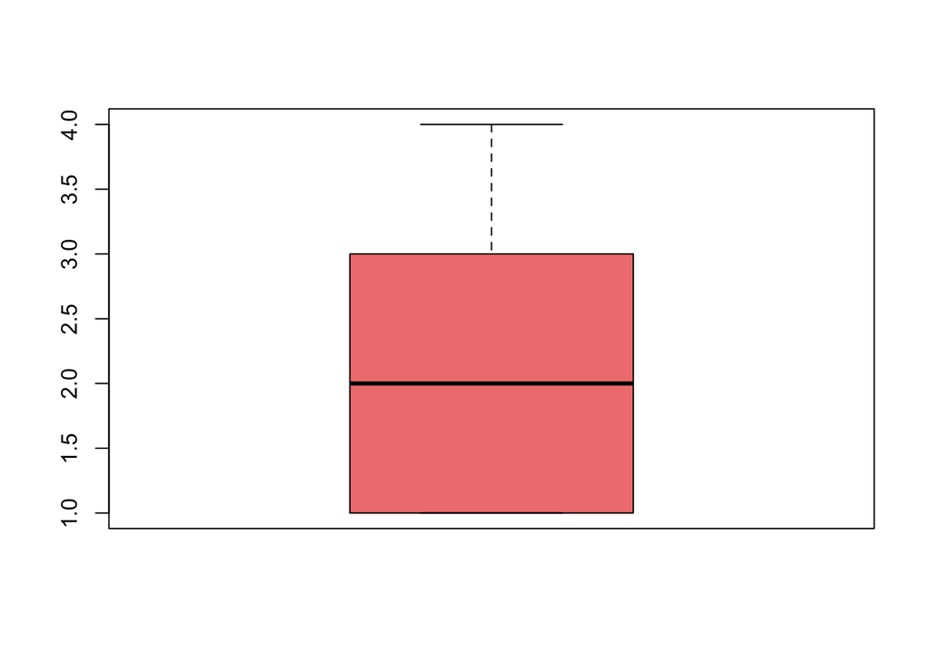

```r
boxplot(km$cluster,col="lightcoral")
```

```r
kmeans(X2,4,algorithm = "Lloyd",iter.max = 40)
```

```
## K-means clustering with 4 clusters of sizes 220, 75, 89, 38
##
## Cluster means:
##        [,1]
## 1  17.01818
## 2 245.34667
## 3 132.98876
## 4 409.89474
##
## Clustering vector:
##   [1] 1 2 1 1 1 1 2 1 1 1 3 1 3 3 1 1 1 1 2 1 3 1 1 1 1 1 1 2 1 1 1 4 1 3 4 3 4
##  [38] 1 1 1 2 3 2 1 1 2 2 1 1 2 1 1 1 3 1 1 1 3 2 1 4 4 3 1 3 3 1 3 1 4 1 3 4 3
##  [75] 1 1 2 1 1 2 2 1 4 3 2 3 4 1 2 1 1 3 3 1 1 1 1 1 3 1 2 3 1 2 2 1 1 2 3 3 1
## [112] 4 1 1 1 1 1 1 1 1 1 1 1 2 2 1 2 1 2 3 1 1 1 3 3 3 2 4 3 1 1 1 2 4 1 1 1 1
## [149] 1 4 2 1 1 2 2 4 3 1 1 2 1 4 2 3 4 1 3 1 1 1 1 2 3 3 1 3 1 1 1 2 2 1 3 1 1
## [186] 3 3 1 1 3 1 2 1 4 1 2 3 2 4 1 1 1 1 1 1 1 1 1 3 1 1 3 3 1 1 1 3 1 4 3 1 1
## [223] 3 1 2 3 2 1 1 1 3 4 1 3 1 4 2 1 2 3 3 4 3 1 3 1 1 4 4 1 2 4 3 3 1 3 1 1 3
## [260] 4 1 1 1 4 2 1 1 3 1 2 1 2 1 1 2 2 2 2 1 3 1 2 1 4 3 3 1 3 1 3 1 2 2 3 1 2
## [297] 1 1 4 2 1 1 1 1 1 1 2 3 2 1 1 3 2 1 1 3 3 3 2 1 3 1 1 2 2 3 1 1 3 1 1 2 3
## [334] 1 2 2 3 1 1 1 2 3 1 1 4 1 3 3 3 1 2 1 1 4 1 3 1 1 2 1 1 1 3 1 1 1 1 3 3 1
## [371] 2 1 3 4 2 1 1 1 1 1 1 4 3 1 1 1 4 1 2 1 1 3 2 1 4 3 4 3 2 1 1 1 2 1 1 1 1
## [408] 2 2 2 2 4 3 1 1 3 4 1 3 1 1 1
##
## Within cluster sum of squares by cluster:
## [1]  87171.93 113522.99  93558.99 223101.58
##  (between_SS / total_SS =  92.8 %)
##
## Available components:
##
## [1] "cluster"      "centers"      "totss"        "withinss"     "tot.withinss"
## [6] "betweenss"    "size"         "iter"         "ifault"
```

```r
km1=kmeans(X2,4,algorithm = "Lloyd",iter.max = 40)
km1$cluster
```

```
##   [1] 4 3 4 4 4 4 3 4 4 4 2 4 2 2 4 4 4 4 3 4 2 4 4 4 4 4 4 3 4 4 4 1 4 2 1 2 1
##  [38] 4 4 4 3 2 3 4 4 3 3 4 4 3 4 4 4 2 4 4 4 2 3 4 1 1 2 4 2 2 4 2 4 1 4 2 1 2
##  [75] 4 4 3 4 4 3 3 4 1 2 3 2 1 4 3 4 4 2 2 4 4 4 4 4 2 4 3 2 4 3 3 4 4 3 2 2 4
## [112] 1 4 4 4 4 4 4 4 4 4 4 4 3 3 4 3 4 3 2 4 4 4 2 2 2 3 1 2 4 4 4 3 1 4 4 4 4
## [149] 4 1 3 4 4 3 3 1 2 4 4 3 4 1 3 2 1 4 2 4 4 4 4 3 2 2 4 2 4 4 4 3 3 4 2 4 4
## [186] 2 2 4 4 2 4 3 4 1 4 3 2 3 1 4 4 4 4 4 4 4 4 4 2 4 4 2 2 4 4 4 2 4 1 2 4 4
## [223] 2 4 3 2 3 4 4 4 2 1 4 2 4 1 3 4 3 2 2 1 2 4 2 4 4 1 1 4 3 1 2 2 4 2 4 4 2
## [260] 1 4 4 4 1 3 4 4 2 4 3 4 3 4 4 3 3 3 3 4 2 4 3 4 1 2 2 4 2 4 2 4 3 3 2 4 3
## [297] 4 4 1 3 4 4 4 4 4 4 3 2 3 4 4 2 3 4 4 2 2 2 3 4 2 4 4 3 3 2 4 4 2 4 4 3 2
## [334] 4 3 3 2 4 4 4 3 2 4 4 1 4 2 2 2 4 3 4 4 1 4 2 4 4 3 4 4 4 2 4 4 4 4 2 2 4
## [371] 3 4 2 1 3 4 4 4 4 4 4 1 2 4 4 4 1 4 3 4 4 2 3 4 1 2 1 2 3 4 4 4 3 4 4 4 4
## [408] 3 3 3 3 1 2 4 4 2 1 4 2 4 4 4
```

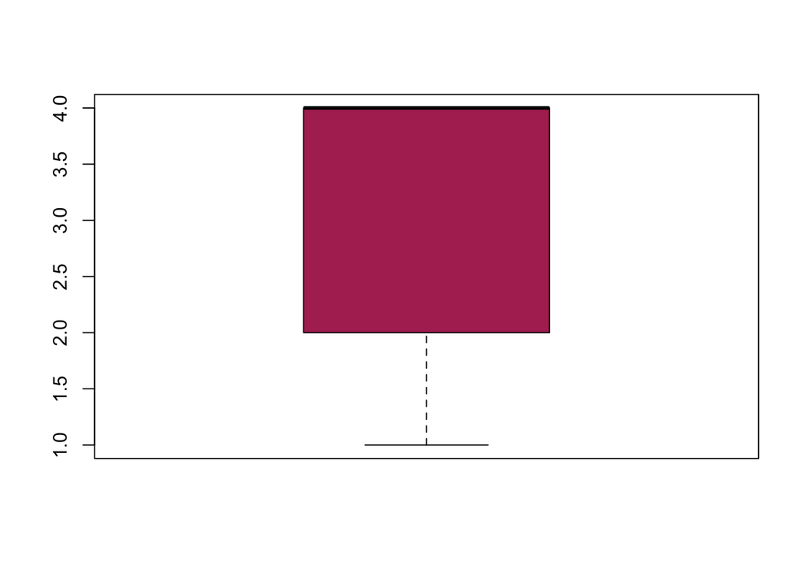

```r
boxplot(km1$cluster,col="maroon")
```

```r
kmeans(X3,4,algorithm = "Lloyd",iter.max = 40)
```

```
## K-means clustering with 4 clusters of sizes 196, 30, 77, 119
##
## Cluster means:
##        [,1]
## 1  28.31633
## 2 404.46667
## 3 226.76623
## 4 118.42857
##
## Clustering vector:
##   [1] 1 3 1 1 4 4 4 4 1 4 4 4 4 1 4 4 1 2 4 4 1 4 1 1 1 1 2 4 4 1 4 3 1 4 4 1 4
##  [38] 1 3 2 4 4 4 3 1 4 3 1 1 4 3 1 1 4 1 4 4 3 1 1 3 1 4 4 3 1 1 1 4 2 1 1 4 1
##  [75] 1 1 3 1 4 4 3 1 2 1 3 1 4 1 1 1 1 1 3 4 1 4 2 1 2 2 3 3 2 3 4 1 1 3 4 4 1
## [112] 3 1 1 1 3 1 1 1 3 3 1 3 2 4 1 4 1 4 4 1 1 1 1 1 4 4 4 3 2 4 1 3 2 3 1 2 1
## [149] 1 1 4 1 4 1 1 2 4 4 1 4 1 3 1 4 2 4 1 1 1 1 1 1 4 3 1 1 1 1 1 3 2 1 3 1 1
## [186] 1 3 1 1 4 1 2 3 3 3 4 1 1 3 1 1 4 1 4 1 1 1 1 1 3 1 4 1 1 4 1 1 1 1 4 1 1
## [223] 1 1 3 4 3 1 4 3 4 4 1 4 1 2 3 4 4 1 4 3 3 4 1 4 1 4 3 1 1 2 2 4 1 4 1 1 4
## [260] 2 1 1 4 2 4 1 3 1 1 3 1 3 2 3 4 4 4 3 1 3 3 4 2 4 1 1 1 1 1 3 3 3 4 1 1 4
## [297] 1 1 3 3 1 3 3 1 1 1 4 1 3 3 1 4 4 1 3 3 4 1 1 1 1 2 1 2 3 4 1 1 1 4 1 4 4
## [334] 3 1 1 4 1 1 4 3 4 1 1 3 4 4 3 1 3 2 3 1 4 1 4 1 1 4 1 1 4 4 1 4 1 1 1 1 1
## [371] 3 1 1 2 1 1 3 3 4 1 4 1 1 4 3 1 4 3 3 1 4 4 1 1 4 4 4 1 2 1 4 1 3 3 1 1 1
## [408] 2 1 1 4 4 4 1 1 1 4 1 3 3 4 1
##
## Within cluster sum of squares by cluster:
## [1]  91476.39 298183.47 116133.79  98721.14
##  (between_SS / total_SS =  89.1 %)
##
## Available components:
##
## [1] "cluster"      "centers"      "totss"        "withinss"     "tot.withinss"
## [6] "betweenss"    "size"         "iter"         "ifault"
```